# Exploratory and Explanatory Analysis of Prosper Loan Dataset

## Preliminary Wrangling

> This document explores a dataset containing loan details of 113,937 of loan holders.

```python
# import all packages and set plots to be embedded inline
import numpy as np
import pandas as pd
import matplotlib.pyplot as plt
import seaborn as sb

%matplotlib inline
```

```python
loan = pd.read_csv('prosperLoanData.csv')
```

```python
#checking for shape and data types
print(loan.shape)
print(loan.dtypes)
```

```
(113937, 81)
ListingKey                              object
ListingNumber                            int64
ListingCreationDate                     object
CreditGrade                             object
Term                                     int64
LoanStatus                              object
ClosedDate                              object
BorrowerAPR                            float64
BorrowerRate                           float64
LenderYield                            float64
EstimatedEffectiveYield                float64
EstimatedLoss                          float64
EstimatedReturn                        float64
ProsperRating (numeric)                float64
ProsperRating (Alpha)                   object
ProsperScore                           float64
ListingCategory (numeric)                int64
BorrowerState                           object
Occupation                              object
EmploymentStatus                        object
EmploymentStatusDuration               float64
IsBorrowerHomeowner                       bool
CurrentlyInGroup                          bool
GroupKey                                object
DateCreditPulled                        object
CreditScoreRangeLower                  float64
CreditScoreRangeUpper                  float64
FirstRecordedCreditLine                 object
CurrentCreditLines                     float64
OpenCreditLines                        float64
                                        ...
TotalProsperLoans                      float64
TotalProsperPaymentsBilled             float64
OnTimeProsperPayments                  float64
ProsperPaymentsLessThanOneMonthLate    float64
ProsperPaymentsOneMonthPlusLate        float64
ProsperPrincipalBorrowed               float64
ProsperPrincipalOutstanding            float64
ScorexChangeAtTimeOfListing            float64
```

[output cut: 8 more lines]

```
MonthlyLoanPayment                     float64
LP_CustomerPayments                    float64
LP_CustomerPrincipalPayments           float64
LP_InterestandFees                     float64
LP_ServiceFees                         float64
LP_CollectionFees                      float64
LP_GrossPrincipalLoss                  float64
LP_NetPrincipalLoss                    float64
LP_NonPrincipalRecoverypayments        float64
PercentFunded                          float64
Recommendations                          int64
InvestmentFromFriendsCount               int64
InvestmentFromFriendsAmount            float64
Investors                                int64
Length: 81, dtype: object
```

```python
loan.head()
```

|  | ListingKey | ListingNumber | ListingCreationDate | CreditGrade | Term | LoanStatus | ClosedDate | BorrowerAPR | BorrowerRate | LenderYield | ... | LP_ServiceFees | LP_CollectionFees | LP_GrossPrincipalLoss | LP_NetPrincipalLoss | LP_NonPrincipalRecoverypayments | PercentFunded | Recommendations | InvestmentFromFriendsCount | InvestmentFromFriendsAmount | Investors |
| --- | --- | --- | --- | --- | --- | --- | --- | --- | --- | --- | --- | --- | --- | --- | --- | --- | --- | --- | --- | --- | --- |
| 0 | 1021339766868145413AB3B | 193129 | 2007-08-26 19:09:29.263000000 | C | 36 | Completed | 2009-08-14 00:00:00 | 0.16516 | 0.1580 | 0.1380 | ... | -133.18 | 0.0 | 0.0 | 0.0 | 0.0 | 1.0 | 0 | 0 | 0.0 | 258 |
| 1 | 10273602499503308B223C1 | 1209647 | 2014-02-27 08:28:07.900000000 | NaN | 36 | Current | NaN | 0.12016 | 0.0920 | 0.0820 | ... | 0.00 | 0.0 | 0.0 | 0.0 | 0.0 | 1.0 | 0 | 0 | 0.0 | 1 |
| 2 | 0EE9337825851032864889A | 81716 | 2007-01-05 15:00:47.090000000 | HR | 36 | Completed | 2009-12-17 00:00:00 | 0.28269 | 0.2750 | 0.2400 | ... | -24.20 | 0.0 | 0.0 | 0.0 | 0.0 | 1.0 | 0 | 0 | 0.0 | 41 |
| 3 | 0EF5356002482715299901A | 658116 | 2012-10-22 11:02:35.010000000 | NaN | 36 | Current | NaN | 0.12528 | 0.0974 | 0.0874 | ... | -108.01 | 0.0 | 0.0 | 0.0 | 0.0 | 1.0 | 0 | 0 | 0.0 | 158 |
| 4 | 0F023589499656230C5E3E2 | 909464 | 2013-09-14 18:38:39.097000000 | NaN | 36 | Current | NaN | 0.24614 | 0.2085 | 0.1985 | ... | -60.27 | 0.0 | 0.0 | 0.0 | 0.0 | 1.0 | 0 | 0 | 0.0 | 20 |

5 rows × 81 columns

```python
loan.info()
```

```
<class 'pandas.core.frame.DataFrame'>
RangeIndex: 113937 entries, 0 to 113936
Data columns (total 81 columns):
ListingKey                             113937 non-null object
ListingNumber                          113937 non-null int64
ListingCreationDate                    113937 non-null object
CreditGrade                            28953 non-null object
Term                                   113937 non-null int64
LoanStatus                             113937 non-null object
ClosedDate                             55089 non-null object
BorrowerAPR                            113912 non-null float64
BorrowerRate                           113937 non-null float64
LenderYield                            113937 non-null float64
EstimatedEffectiveYield                84853 non-null float64
EstimatedLoss                          84853 non-null float64
EstimatedReturn                        84853 non-null float64
ProsperRating (numeric)                84853 non-null float64
ProsperRating (Alpha)                  84853 non-null object
ProsperScore                           84853 non-null float64
ListingCategory (numeric)              113937 non-null int64
BorrowerState                          108422 non-null object
Occupation                             110349 non-null object
EmploymentStatus                       111682 non-null object
EmploymentStatusDuration               106312 non-null float64
IsBorrowerHomeowner                    113937 non-null bool
CurrentlyInGroup                       113937 non-null bool
GroupKey                               13341 non-null object
DateCreditPulled                       113937 non-null object
CreditScoreRangeLower                  113346 non-null float64
CreditScoreRangeUpper                  113346 non-null float64
FirstRecordedCreditLine                113240 non-null object
CurrentCreditLines                     106333 non-null float64
OpenCreditLines                        106333 non-null float64
TotalCreditLinespast7years             113240 non-null float64
OpenRevolvingAccounts                  113937 non-null int64
OpenRevolvingMonthlyPayment            113937 non-null float64
InquiriesLast6Months                   113240 non-null float64
TotalInquiries                         112778 non-null float64
CurrentDelinquencies                   113240 non-null float64
AmountDelinquent                       106315 non-null float64
```

[output cut: 31 more lines]

```
LP_CustomerPayments                    113937 non-null float64
LP_CustomerPrincipalPayments           113937 non-null float64
LP_InterestandFees                     113937 non-null float64
LP_ServiceFees                         113937 non-null float64
LP_CollectionFees                      113937 non-null float64
LP_GrossPrincipalLoss                  113937 non-null float64
LP_NetPrincipalLoss                    113937 non-null float64
LP_NonPrincipalRecoverypayments        113937 non-null float64
PercentFunded                          113937 non-null float64
Recommendations                        113937 non-null int64
InvestmentFromFriendsCount             113937 non-null int64
InvestmentFromFriendsAmount            113937 non-null float64
Investors                              113937 non-null int64
dtypes: bool(3), float64(50), int64(11), object(17)
memory usage: 68.1+ MB
```

### Structure of dataset

> The dataset contains 113,937 rows and 81 columns containing the loan informations

### Main feature(s) of interest

> Loan status is the main feature of interest containing information of Loan like Chargeoff, Current, Defaulted etc.

### Features in the dataset will help support investigation into Feature(s) of interest

> Term, Loan Amount and Employment Status might be a deterministic factor in Loan Status

## Univariate Exploration

### Let's check the distribution of the Loan Amount

```python
loan.LoanOriginalAmount.describe()
```

```
count    113937.00000
mean       8337.01385
std        6245.80058
min        1000.00000
25%        4000.00000
50%        6500.00000
75%       12000.00000
max       35000.00000
Name: LoanOriginalAmount, dtype: float64
```

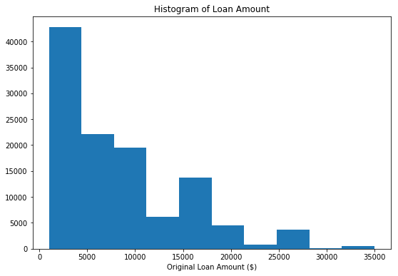

```python
bin_size = 2500
bins = np.arange(0, loan['LoanOriginalAmount'].max()+bin_size, bin_size)

plt.figure(figsize = [9, 6])
plt.hist(data = loan, x = 'LoanOriginalAmount');
plt.xlabel('Original Loan Amount ($)')
plt.title('Histogram of Loan Amount');
```

> We see the distribution of the Loan Amount is highly Right Skewed so we take a log transformation of the data

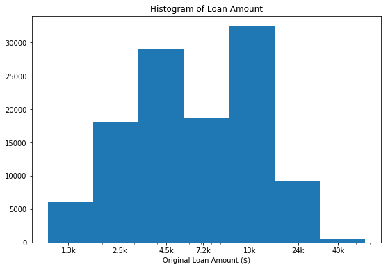

```python
log_binsize = 0.25
bins = 10 ** np.arange(3, np.log10(loan['LoanOriginalAmount']).max()+log_binsize, log_binsize)
plt.figure(figsize = [9, 6])
plt.hist(data = loan, x = 'LoanOriginalAmount', bins = bins);
plt.xscale('log')
plt.xticks([1.3e3, 2.5e3, 4.5e3, 7.2e3, 13e3, 24e3, 40e3], ['1.3k', '2.5k', '4.5k', '7.2k', '13k', '24k', '40k'])
plt.xlabel('Original Loan Amount ($)')
plt.title('Histogram of Loan Amount');
```

> Here, we observe that the distribution of the datasets is bimodal, one peak lies between 3500 and 600 and the second peak lies between 10000 and 20000.

### Let's explore the LoanStatus distribution

```python
loan.LoanStatus.value_counts()
```

```
Current                   56576
Completed                 38074
Chargedoff                11992
Defaulted                  5018
Past Due (1-15 days)        806
Past Due (31-60 days)       363
Past Due (61-90 days)       313
Past Due (91-120 days)      304
Past Due (16-30 days)       265
FinalPaymentInProgress      205
Past Due (>120 days)         16
Cancelled                     5
Name: LoanStatus, dtype: int64
```

> Combining all Past Dues in a single column

```python
loan1 = loan.copy()
loan1['Status'], loan1['LoanStatus_2'] = loan1.LoanStatus.str.split('(', 1).str
loan1 = loan1.drop(['LoanStatus_2'], axis=1)
loan1.head()
```

|  | ListingKey | ListingNumber | ListingCreationDate | CreditGrade | Term | LoanStatus | ClosedDate | BorrowerAPR | BorrowerRate | LenderYield | ... | LP_CollectionFees | LP_GrossPrincipalLoss | LP_NetPrincipalLoss | LP_NonPrincipalRecoverypayments | PercentFunded | Recommendations | InvestmentFromFriendsCount | InvestmentFromFriendsAmount | Investors | Status |
| --- | --- | --- | --- | --- | --- | --- | --- | --- | --- | --- | --- | --- | --- | --- | --- | --- | --- | --- | --- | --- | --- |
| 0 | 1021339766868145413AB3B | 193129 | 2007-08-26 19:09:29.263000000 | C | 36 | Completed | 2009-08-14 00:00:00 | 0.16516 | 0.1580 | 0.1380 | ... | 0.0 | 0.0 | 0.0 | 0.0 | 1.0 | 0 | 0 | 0.0 | 258 | Completed |
| 1 | 10273602499503308B223C1 | 1209647 | 2014-02-27 08:28:07.900000000 | NaN | 36 | Current | NaN | 0.12016 | 0.0920 | 0.0820 | ... | 0.0 | 0.0 | 0.0 | 0.0 | 1.0 | 0 | 0 | 0.0 | 1 | Current |
| 2 | 0EE9337825851032864889A | 81716 | 2007-01-05 15:00:47.090000000 | HR | 36 | Completed | 2009-12-17 00:00:00 | 0.28269 | 0.2750 | 0.2400 | ... | 0.0 | 0.0 | 0.0 | 0.0 | 1.0 | 0 | 0 | 0.0 | 41 | Completed |
| 3 | 0EF5356002482715299901A | 658116 | 2012-10-22 11:02:35.010000000 | NaN | 36 | Current | NaN | 0.12528 | 0.0974 | 0.0874 | ... | 0.0 | 0.0 | 0.0 | 0.0 | 1.0 | 0 | 0 | 0.0 | 158 | Current |
| 4 | 0F023589499656230C5E3E2 | 909464 | 2013-09-14 18:38:39.097000000 | NaN | 36 | Current | NaN | 0.24614 | 0.2085 | 0.1985 | ... | 0.0 | 0.0 | 0.0 | 0.0 | 1.0 | 0 | 0 | 0.0 | 20 | Current |

5 rows × 82 columns

```python
loan1.Status.value_counts()
```

```
Current                   56576
Completed                 38074
Chargedoff                11992
Defaulted                  5018
Past Due                   2067
FinalPaymentInProgress      205
Cancelled                     5
Name: Status, dtype: int64
```

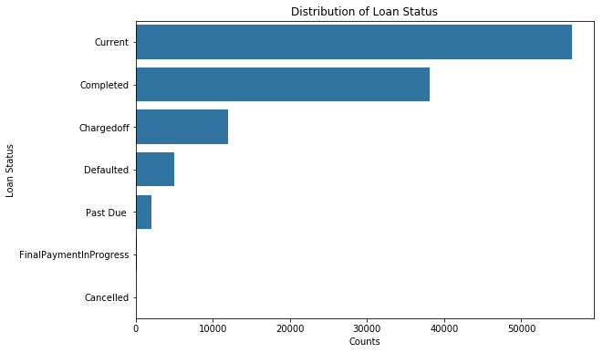

```python
base_color = sb.color_palette()[0]
plt.figure(figsize = [9, 6])
type_order = loan1['Status'].value_counts().index
sb.countplot(data = loan1, y = 'Status', color = base_color, order = type_order);
plt.ylabel('Loan Status')
plt.xlabel('Counts')
plt.title('Distribution of Loan Status');
```

> We see most of the Loan Status is either Completed or Current, while counts corresponding to PastDue, Canceled, InProgress is less. Let's further look into percentages.

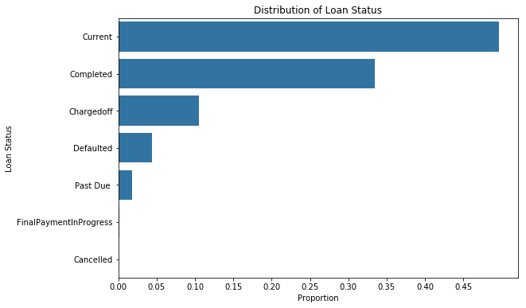

```python
base_color = sb.color_palette()[0]
plt.figure(figsize = [9, 6])
type_counts = loan1['Status'].value_counts()
type_order = loan1['Status'].value_counts().index
n_loan1 = loan1.shape[0]
max_type_count = type_counts[0]
max_prop = max_type_count / n_loan1
tick_props = np.arange(0, max_prop, 0.05)
tick_names = ['{:0.2f}'.format(v) for v in tick_props]
sb.countplot(data = loan1, y = 'Status', color = base_color, order = type_order);
plt.xticks(tick_props*n_loan1, tick_names)
plt.ylabel('Loan Status')
plt.xlabel('Proportion')
plt.title('Distribution of Loan Status');
```

> Thus the above plot shows that more than 45% of the loans are in current, while more than 30% are completed.

## Bivariate Exploration

### Is there relationship between Loan Amount and Term

```python
loan1.Term.value_counts()
```

```
36    87778
60    24545
12     1614
Name: Term, dtype: int64
```

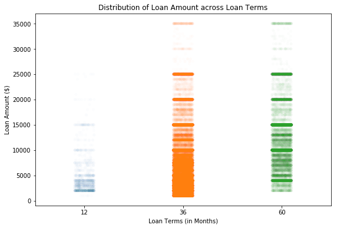

```python
plt.figure(figsize = [9, 6])
sb.stripplot(data = loan1, x = 'Term', y = 'LoanOriginalAmount', jitter = True, alpha = 1/100);
plt.xlabel('Loan Terms (in Months)')
plt.ylabel('Loan Amount ($)')
plt.title('Distribution of Loan Amount across Loan Terms');
```

> We see that there is only 3 loan terms avaialable, 12 months, 36 months and 60 months. And most of the high Loan Terms are corresponding to 36 or 60 months which is quiet natural

### Relationship between Loan Amount and Employment Status

```python
loan1.EmploymentStatus.value_counts()
```

```
Employed         67322
Full-time        26355
Self-employed     6134
Not available     5347
Other             3806
Part-time         1088
Not employed       835
Retired            795
Name: EmploymentStatus, dtype: int64
```

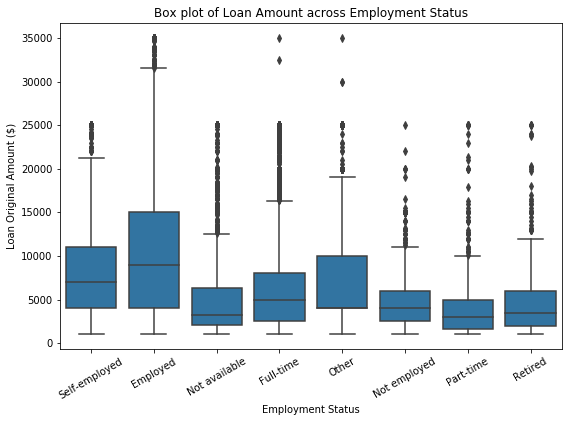

```python
base_color = sb.color_palette()[0]
plt.figure(figsize = [9, 6])
sb.boxplot(data = loan1, x = 'EmploymentStatus', y = 'LoanOriginalAmount', color = base_color);
plt.xticks(rotation = 30);
plt.xlabel('Employment Status')
plt.ylabel('Loan Original Amount ($)')
plt.title('Box plot of Loan Amount across Employment Status');
```

> Here it is seen that Employed and Self-Employed Customers are granted higher Loan as compared to Not employed and Part-Time

### Relationship between Loan Amount and Loan Status

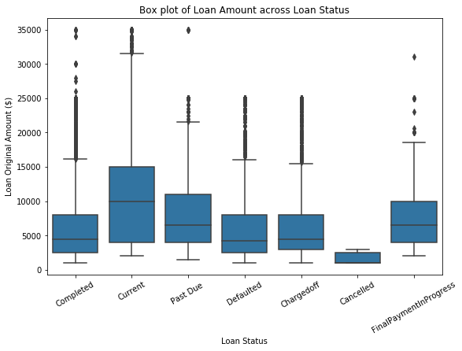

```python
base_color = sb.color_palette()[0]
plt.figure(figsize = [9, 6])
sb.boxplot(data = loan1, x = 'Status', y = 'LoanOriginalAmount', color = base_color);
plt.xticks(rotation = 30);
plt.xlabel('Loan Status')

plt.ylabel('Loan Original Amount ($)')
plt.title('Box plot of Loan Amount across Loan Status');
```

> We see most of the High Loan Amounts are in Current and Final Payment Progress state, which is very good sign. But there are some Past Due which overlays potential threat. Loan Amount Corresponding to Completed, Defaulted and Chargeoff are pretty less.

### Relationship between Employment Status and Loan Status

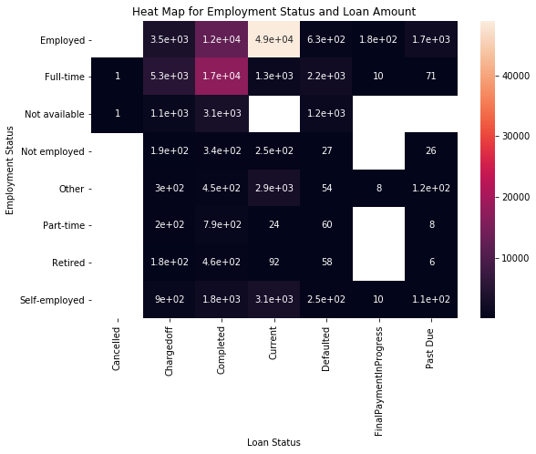

```python
import statsmodels.api
color_base = sb.color_palette()[0]
plt.figure(figsize = [9, 6])
ct_counts = loan1.groupby(['EmploymentStatus', 'Status']).size()
ct_counts = ct_counts.reset_index(name = 'count')
ct_counts = ct_counts.pivot(index = 'EmploymentStatus', columns = 'Status', values = 'count')
sb.heatmap(ct_counts, annot = True, color = color_base);
plt.xlabel('Loan Status')
plt.ylabel('Employment Status')
plt.title('Heat Map for Employment Status and Loan Amount');
```

## Multivariate Exploration

### Relationship between LoanAmount, Loan Status, EmploymentStatus and Loan Term

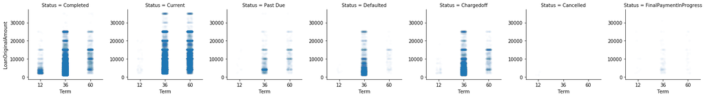

```python
g = sb.FacetGrid(data = loan1, col = 'Status', margin_titles = True)
g.map(sb.stripplot, 'Term', 'LoanOriginalAmount', jitter = True, alpha = 1/100);
```

> Here it is observed that Loan higher than 30000 for 36 months and 60 months are mostly Completed or in Current state whilevery few is Past Due. While some Loans between 20000 and 30000 for both 36 and 60 months is Defaulted or Charged off.

### Relationship between Loan Amount, Loan Status and Employment Status

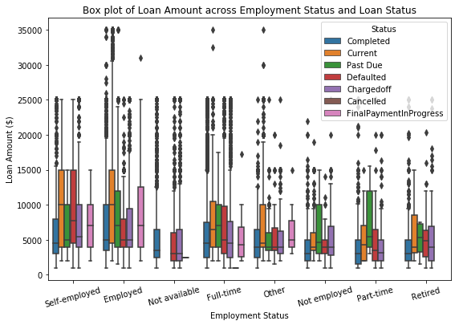

```python
plt.figure(figsize = [9, 6])
sb.boxplot(data = loan1, x = 'EmploymentStatus', y = 'LoanOriginalAmount', hue = 'Status');
plt.xticks(rotation = 15)
plt.xlabel('Employment Status')
plt.ylabel('Loan Amount ($)')
plt.title('Box plot of Loan Amount across Employment Status and Loan Status');
```

> Thus it is seen that High Loan Amounts alloted to Employed and Self-Employed are in 'Current' state. While small Loan Amount alloted to Self-employed, Employed and Full-time employees have been completed. But there also instances that Large Amount alotted to Self-employed have been defaulted which is potential threat.